# TD_GMM

ISLA Thomas

02/12/2020

# GMM vs K-Means

**Question 1**

```r
data1=read.csv(file = "data1.csv",header=TRUE)
head(data1,5)
```

```
##         X1         X2 truth
## 1 6.488267  0.2500645     4
## 2 2.521947 -2.6979865     3
## 3 3.068773 -2.9000760     3
## 4 4.314275  0.7029506     1
## 5 2.384499 -2.5356349     3
```

```r
data2=read.csv(file = "data2.csv",header=TRUE)
head(data2,5)
```

```
##           X1         X2 truth
## 1  9.0650131  3.6693087     4
## 2 -0.2505132 -0.9810086     3
## 3  0.2121641 -0.8639544     3
## 4  6.7522538  2.9020410     1
## 5 -0.2161893 -0.9143583     3
```

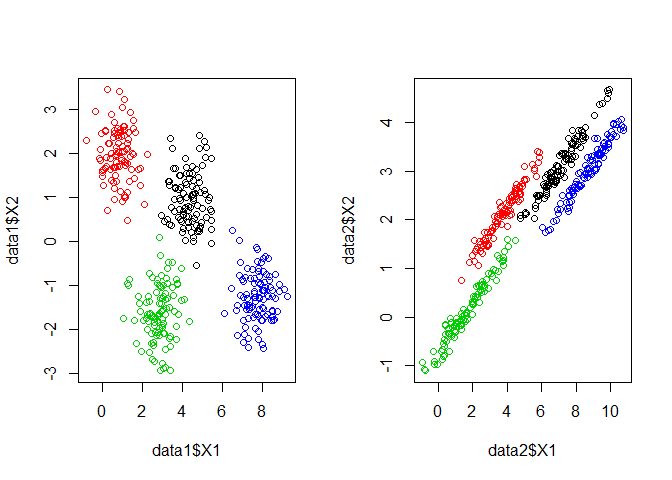

```r
par(mfrow=c(1,2))
plot(data1$X1,data1$X2,col=data1$truth)
plot(data2$X1,data2$X2,col=data2$truth)
```

Chaque dataset est constitué de quatre groupes plutot bien séparés. Les groupes du premier dataset ont une allure sphérique on peut donc appliquer un algorithme K-means sur ce dataset.

Les groupes du second dataset ont une allure d’ellipse, on peut en tirer deux informations: + les variables X1 et X2 sont corrélées et plutot fortement vu l’allure des ellipse. + sur ce dataset un algorithme K-means risque de ne pas être très performant.

Combien d’individus par cluster dans notre dataset 1?

```r
table(data1$truth)
```

```
##
##   1   2   3   4
## 100 100 100 100
```

Combien d’individus par cluster dans notre dataset 2?

```r
table(data2$truth)
```

```
##
##   1   2   3   4
## 100 100 100 100
```

Donc chaque cluster contient 100 individus.

**Question 2**

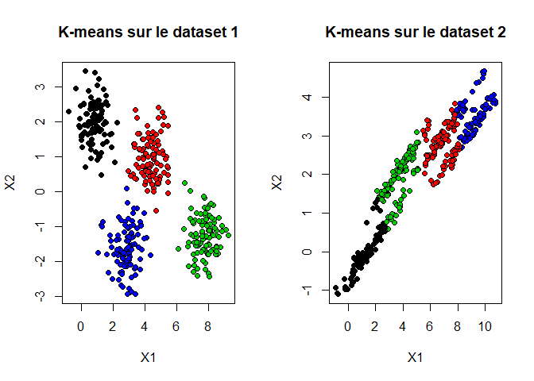

```r
set.seed(54654)
km1 <- kmeans(data1[,1:2], 4)
km2 <- kmeans(data2[,1:2], 4)
par(mfrow=c(1,2))
plot(data1[,1:2], pch=21, bg=km1$cluster,main="K-means sur le dataset 1")
plot(data2[,1:2], pch=21, bg=km2$cluster,main="K-means sur le dataset 2")
```

On remarque la méthode k-means donne de bons résultats pour le premier dataset. Cela est logique car les groupes sont plutot bien définis et ont une forme sphérique.

Cependant la méthode n’est pas satisfaisante pour le second dataset. L’algorithme n’arrive pas à capter la forme ellipsoïdale des groupes. Pour ce second dataset il semble préférable d’utiliser l’algorithme GMM.

```r
table(km1$cluster)
```

```
##
##   1   2   3   4
## 100 100 100 100
```

```r
table(km2$cluster)
```

```
##
##   1   2   3   4
##  87 110 110  93
```

On complête nos impressions du graphiques avec cette étape. L’algorithme k-means a bien trouvé 100 individus pour chaque cluster du premier dataset. Concernant le second dataset, il n’arrive pas correctement à identifier à quel cluster les individus appartiennent. Deux des clusters sont amputés d’une dizaine d’individus tandis que les deux autres ont une dizaine d’individu supplémentaire.

**Question 3**

```r
library(mclust)
```

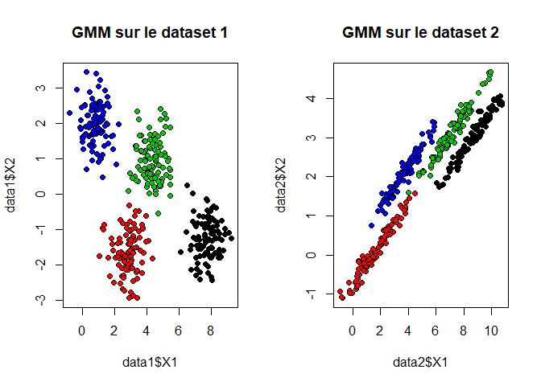

```r
GMM1=Mclust(data = data1[,1:2])
GMM2=Mclust(data = data2[,1:2])
par(mfrow=c(1,2))
plot(data1$X1,data1$X2,bg=GMM1$classification,pch=21,main="GMM sur le dataset 1")
plot(data2$X1,data2$X2,bg=GMM2$classification,pch=21,main="GMM sur le dataset 2")
```

Pour les deux datasets les résultats sont très satisfaisant. On remarque qu’il est moins performant que l’algorithme k-means sur le premier dataset, on observe une valeur mal classée. Il est cependant beaucoup plus performant sur le second dataset.

```r
table(GMM1$classification)
```

```
##
##   1   2   3   4
## 100  99 101 100
```

```r
table(GMM2$classification)
```

```
##
##   1   2   3   4
## 100  99 101 100
```

Comme visualiser, une unique erreur sur le premier dataset. Une unique erreur également sur le second dataset.

**Question 4**

```r
summary(GMM1)
```

```
## ----------------------------------------------------
## Gaussian finite mixture model fitted by EM algorithm
## ----------------------------------------------------
##
## Mclust EII (spherical, equal volume) model with 4 components:
##
##  log-likelihood   n df       BIC       ICL
##       -1267.662 400 12 -2607.221 -2611.471
##
## Clustering table:
##   1   2   3   4
## 100  99 101 100
```

```r
summary(GMM2)
```

```
## ----------------------------------------------------
## Gaussian finite mixture model fitted by EM algorithm
## ----------------------------------------------------
##
## Mclust EEE (ellipsoidal, equal volume, shape and orientation) model with 4
## components:
##
##  log-likelihood   n df       BIC       ICL
##       -938.8639 400 14 -1961.608 -1965.709
##
## Clustering table:
##   1   2   3   4
## 100  99 101 100
```

**Question 5**

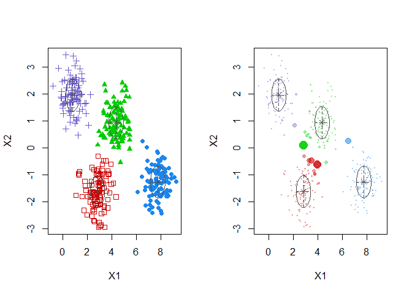

```r
par(mfrow=c(1,2))
plot(GMM1, what = "classification",main="Classification plot of dataset One")
plot(GMM1, what = "uncertainty",main="Classification plot of dataset One")
```

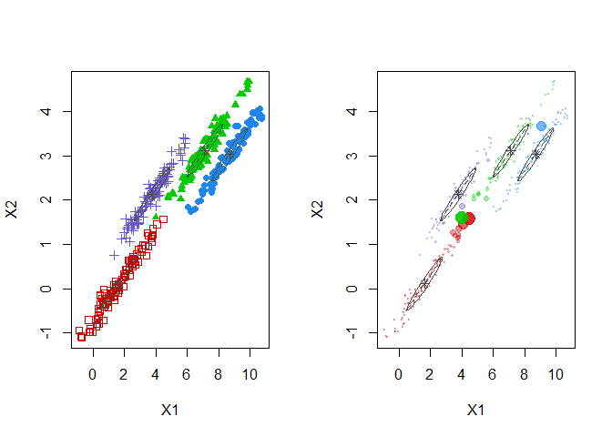

```r
par(mfrow=c(1,2))
plot(GMM2, what = "classification",main="Classification plot of dataset Two")
plot(GMM2, what = "uncertainty",main="Classification plot of dataset Two")
```

Essayons de plot notre distribution du premier dataset en 3D:

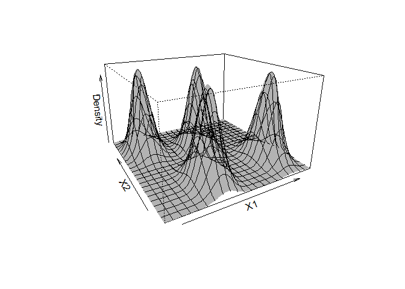

```r
dens = densityMclust(data1[,1:2])
plot(dens, what = "density", type = "persp")
```

On observe 4 gaussiennes d’où la précence de quatre clusters.

**Question 6**

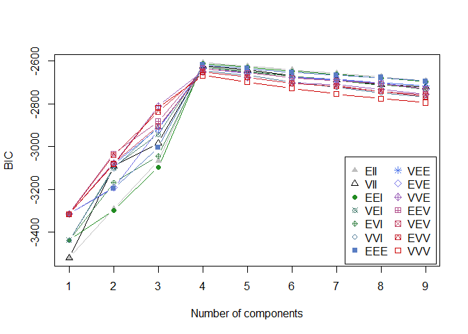

```r
plot(GMM1, what="BIC")
```

La forme de l’ellipse ne semble pas avoir d’impact sur la qualité du modèle donc dans ce cas on peut en déduire qu’ici la forme ellipsoïdale n’a pas grand intêret, un k-means ferait-il l’affaire?

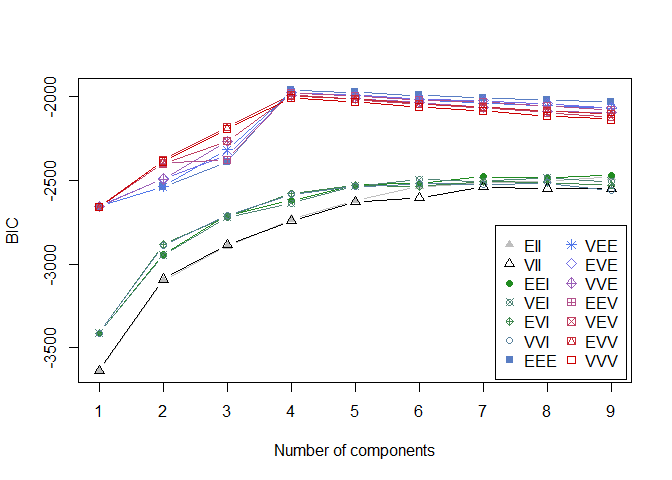

```r
plot(GMM2, what="BIC")
```

Pour le second dataset, le meilleure score BIC est obtenu lorsque le nombre de cluster est 4 et lorsque les ellipses ont une forme EEE.

**Question 7**

```r
dens2=densityMclust(data2[,1:2])
summary(dens2)
```

```
## -------------------------------------------------------
## Density estimation via Gaussian finite mixture modeling
## -------------------------------------------------------
##
## Mclust EEE (ellipsoidal, equal volume, shape and orientation) model with 4
## components:
##
##  log-likelihood   n df       BIC       ICL
##       -938.8639 400 14 -1961.608 -1965.709
```

```r
head(dens$density)
```

```
## [1] 0.0005217424 0.0190907046 0.0104957132 0.1061984192 0.0258499004
## [6] 0.0863022163
```

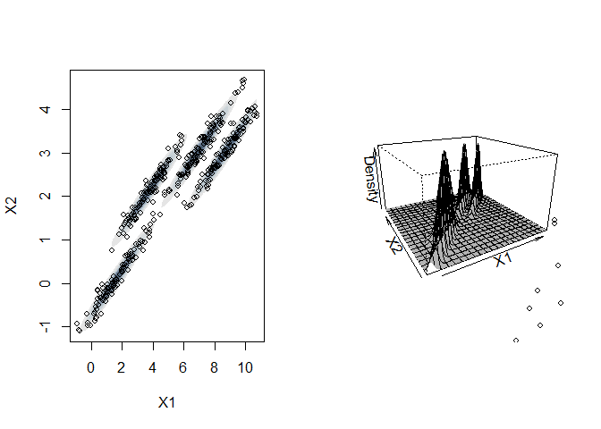

```r
par(mfrow=c(1,2))
plot(dens2, what = 'density',data = data2[,1:2], type = "hdr", prob = seq(0.1, 0.9, by = 0.1), col = "slategrey")
plot(dens2, what = 'density',data = data2[,1:2], type = "persp", prob = seq(0.1, 0.9, by = 0.1))
```

```r
GMM2$df
```

```
## [1] 14
```

On a une representation en 3D de notre densité. On a également une représentation 2D, cette dernière pourrait servir à estimer la précense ou non d’outliers dans le dataset. On se rend compte que certaines données sont à l’extérieur de l’ellipse qui représente la densité. Dans un véritable dataset nous devrions observer attentivement ces valeurs.

# EM on ONE-D

**Question 8**

```r
n=100
set.seed(1)
y=c(rnorm(n,-5),rnorm(n,0),rnorm(n,5))
yclass=c(rep(1,n),rep(2,n),rep(3,n))
```

**Question 9**

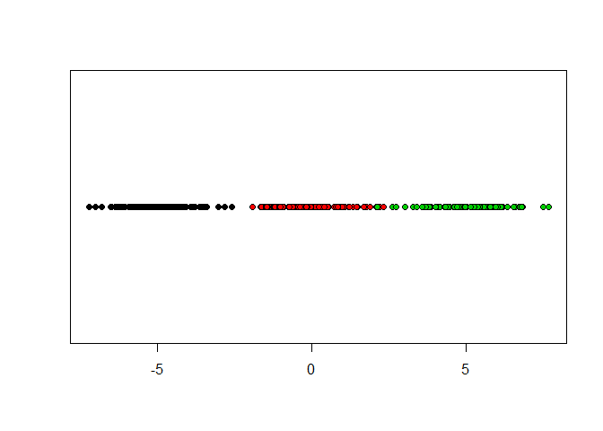

```r
stripchart(y,pch=21,bg=yclass)
```

**Question 10**

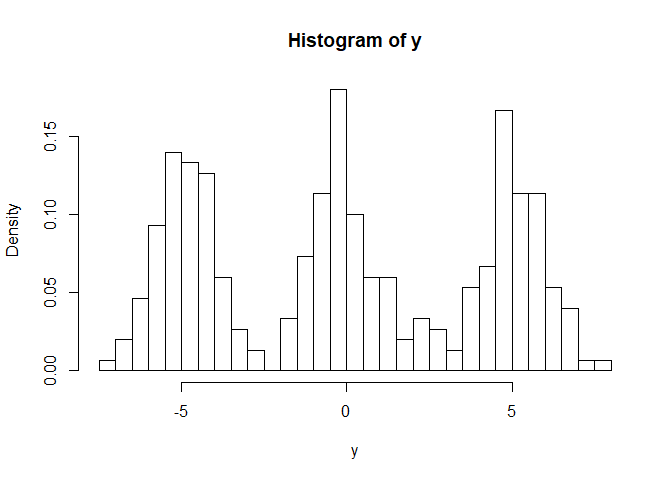

```r
hist(y,30,probability = TRUE)
```

Le dataset est un mélange de trois gaussiennes. L’une est centrée en -5, l’autre en 0 et la dernière en 5. On s’attends à trouver trois catégories dans notre modèle.

**Question 11**

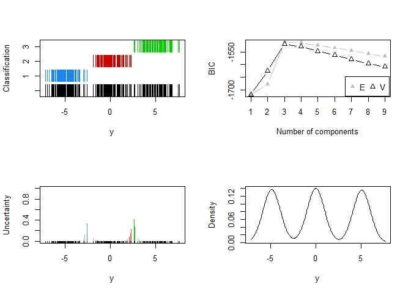

```r
GMM=Mclust(y)
par(mfrow=c(2,2))
plot(GMM, what="classification")
plot(GMM, what="BIC")
plot(GMM, what="uncertainty")
plot(GMM, what="density")
```

Ces graphiques confirment la précence de trois clusters, trois gaussiennes. L’analyse du BIC confirme que les meilleures résultats sont obtenus lorsque le nombre de cluster est 3.

**Question 12**

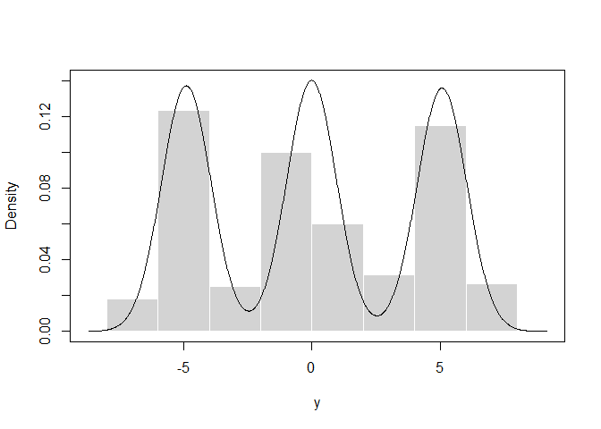

```r
densY=densityMclust(y)
plot(densY,what="density",data=y)
```

Les densités trouvaient par le modèle correspondent aux densités réelle de y.

# Whitening sur le dataset2

L’un des avantages d’un whitening est de décorreler nos variables. Cela ce traduit visuellement par une spérification de l’allure des données. Etant donnée que l’algorithme GMM est performant lorsque les données ont une forme d’ellipse, alors je suppose qu’un whitening va nuire à la performance de mon modèle.

J’ai essayé plusieurs méthodes de whitening.

```r
library(whitening)
data_ZCA=whiten(as.matrix(data2[,1:2]),center = TRUE,method=c("ZCA"))
data_PCA=whiten(as.matrix(data2[,1:2]),center = TRUE,method=c("PCA"))

library(FactoMineR)
```

```r
dataPCA=PCA(data2[,1:2], scale.unit=TRUE, graph=FALSE)

X=dataPCA$ind$coord
X[,1]=X[,1]/sqrt(dataPCA$eig[1])
X[,2]=X[,2]/sqrt(dataPCA$eig[2])
cor(X)
```

```
##              Dim.1        Dim.2
## Dim.1 1.000000e+00 2.054264e-16
## Dim.2 2.054264e-16 1.000000e+00
```

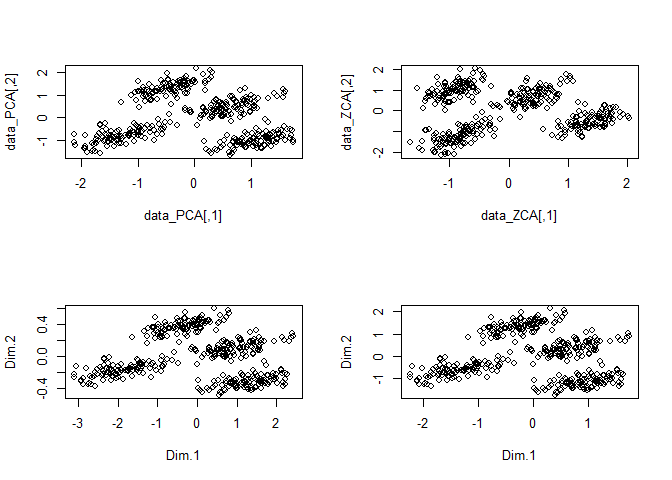

```r
par(mfrow=c(2,2))
plot(data_PCA)
plot(data_ZCA)
plot(dataPCA$ind$coord)
plot(X)
```

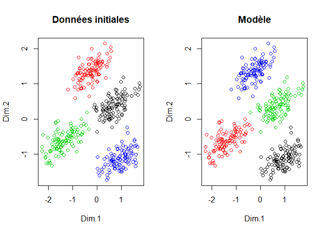

```r
GMM_W=Mclust(data_ZCA)
par(mfrow=c(1,2))
plot(X,col=data2$truth,main="Données initiales")
plot(X,col=GMM_W$classification,main="Modèle")
```

On n’observe pas d’amélioration du modèle, mais on n’observe pas de degradation également.

Sources:

https://rdrr.io/cran/mclust/man/plot.densityMclust.html

https://www.ncbi.nlm.nih.gov/pmc/articles/PMC5096736/